# Handling_files_in_Aurora

### How to handle files in aurora after downloading from Swestore

##### Salma Kazemi Rashed

###### 4th of September

I check the size of file with simple following command:

ls -lh

and then saved all the files' names in a text file and extract them all in a while loop in bash as following:

cat file.txt | while read file; do tar xvzf $file; done

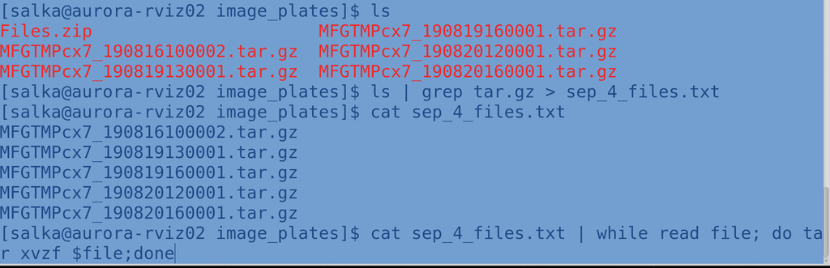

It takes several hours!

After extracting them now we should check that if each folder contains the complete set of images or not. The complete set for each row should be : 16 *24* 3 = 1152

The checking also done by the following bash commands : save the folders in a text file:

ls | grep -v tar.gz | grep -v .txt > sep_4_folders.txt

And then counting the three channels of each image of each row by following command:

cat sep_4_folders.txt | while read file; do ls $file| grep .C01|grep -v o1.C01| grep -v o2.C01|cut -d '_' -f 3|cut -b 1|sort| uniq -c;done

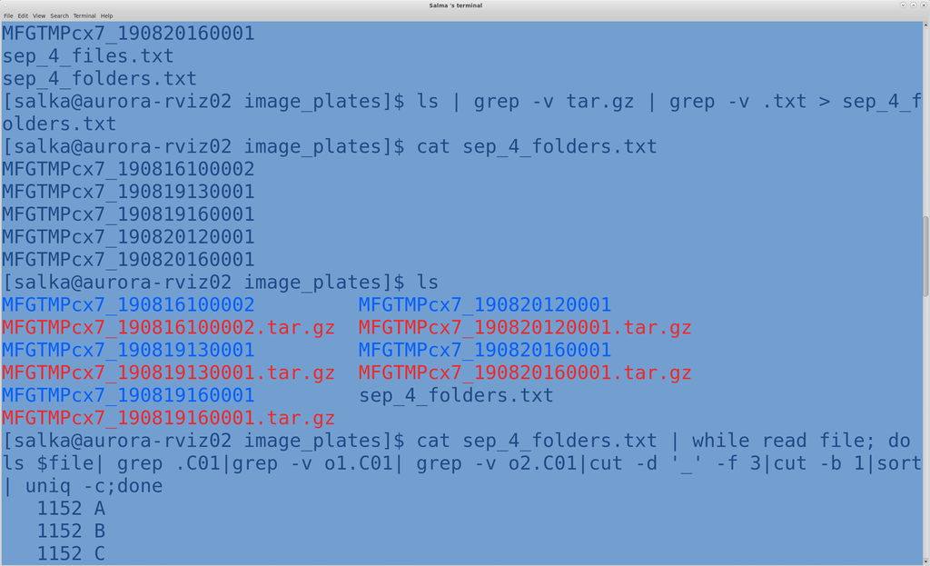

If all rows contain 1152 images, the folder would be a complete set of images and we should keep it.

In this level, we should select the random images from each folder by the following random algorithm as new_selection_algorithm:

Running just as Python3 new_selection_algorithm.py

```python
import os, sys
import random
import glob
import os, sys
from shutil import copyfile

if len(sys.argv)<2:
    folder_path = '/lunarc/nobackup/users/salka/Downloads/image_plates/'
else:
    folder_path = sys.argv[1]
os.chdir(folder_path)
# upper directory of image folders

# BUILD LIST OF PLATES
plate_list = list()
for i in os.listdir():
    print(i)
    if os.path.isdir(i):
        plate_list.append(i)
        print(plate_list)
print('There are {} plates\n'.format(len(plate_list)))
## I had just one folder
##########################################################

C01_files = list()
#C01_names = list()
for i in plate_list:
    print("Path is {}".format(folder_path +  str(i) + '/*.C01'))
    C01_files = glob.glob(folder_path +  str(i) + '/*.C01')
    print('Plate {0} has {1} C01-files'.format(i, len(C01_files)))
    #C01_files = C01_files + C01_files_plate


    print('In total there are {} C01-files on {} plate\n'.format(len(C01_files),i))
    print('\n')

###########################################################################

#####selection from control columns 2 image from each well in column 2, 23
    ctrl_images = []
#random image per control well (32 wells)
    for x in range(32):
        ctrl_images.append(str(random.randint(1,16)-1))

    img_no_ctrl_well_1 = []
    for i in ctrl_images:
        if len(i)==1:
            img_no_ctrl_well_1.append('0'+ i)
        else:
            img_no_ctrl_well_1.append(i)

    print("Image numbers in all first serie of 32 wells would be \n {}".format(img_no_ctrl_well_1))




    ctrl_images_2 = []
    #random image per control well (32 wells)
    for x in range(32):
        tmp_rand = str(random.randint(1,16)-1)
        if tmp_rand ==ctrl_images[x]:
            while(tmp_rand ==ctrl_images[x]):
                tmp_rand = str(random.randint(1,16)-1)
        ctrl_images_2.append(tmp_rand)


    img_no_ctrl_well_2 = []
    for i in ctrl_images_2:
        if len(i)==1:
            img_no_ctrl_well_2.append('0'+ i)
        else:
            img_no_ctrl_well_2.append(i)



    print("Image numbers in all second serie of 32 wells would be \n {}".format(img_no_ctrl_well_2))

#######################################################
    well_images = []
    for i in C01_files:
        if i.split('/')[-1].split('_')[-1][1:3]=="02" or i.split('/')[-1].split('_')[-1][1:3]=="23":
            well_images.append(i)
    print("Total well images are {}".format(len(well_images)))


    selected_well_images=[]
    row_index = ['A','B','C','D','E','F','G','H', 'I', 'J', 'K' , 'L', 'M', 'N', 'O', 'P']
    first_set  =dict(zip(row_index, img_no_ctrl_well_1))
    second_set =dict(zip(row_index, img_no_ctrl_well_2))



    for j in row_index:
        for i in well_images:
            if i.split('/')[-1].split('_')[-1][0:1]== j: #img_no_ctrl_well_1[j]:
                if i.split('/')[-1].split('_')[-1][4:6]== first_set[j] and (i.split('/')[-1].split('_')[-1][6:8]=='d0' or i.split('/')[-1].split('_')[-1][6:8]=='d1' or i.split('/')[-1].split('_')[-1][6:8]=='d2'):
                    selected_well_images.append(i)

    for j in row_index:
        for i in well_images:
            if i.split('/')[-1].split('_')[-1][0:1]== j: #img_no_ctrl_well_1[j]:
                if i.split('/')[-1].split('_')[-1][4:6]== second_set[j] and (i.split('/')[-1].split('_')[-1][6:8]=='d0' or i.split('/')[-1].split('_')[-1][6:8]=='d1' or i.split('/')[-1].split('_')[-1][6:8]=='d2'):
                    selected_well_images.append(i)


    print("Total Control selected images are {} which should be 32 *2 *3 = 192".format(len(selected_well_images)))



##############################################

    extra_ctrl_images_row_1 = []
    #random image per control well (32 wells)
    for x in range(2):
        extra_ctrl_images_row_1.append(row_index[(random.randint(1,16)-1)])
        if x>0 and extra_ctrl_images_row_1[0]==extra_ctrl_images_row_1[1]:
            while(extra_ctrl_images_row_1[0]==extra_ctrl_images_row_1[1]):
                extra_ctrl_images_row_1[0] = row_index[(random.randint(1,16)-1)]
    print(extra_ctrl_images_row_1)

    extra_ctrl_images_1 = []
    #random image per control well (32 wells)
    for x in range(2):
        x = str(random.randint(1,16)-1)
        if len(x)==1:
            extra_ctrl_images_1.append('0'+x)
        else:
            extra_ctrl_images_1.append(x)


    extra_ctrl_images_row_2 = []
    #random image per control well (32 wells)
    for x in range(2):
        tmp_rand = row_index[(random.randint(1,16)-1)]
        extra_ctrl_images_row_2.append(tmp_rand)
    for x in range(2):
        if extra_ctrl_images_row_2[x]==extra_ctrl_images_row_1[x] or extra_ctrl_images_row_2[x]==extra_ctrl_images_row_2[1-x]:
            while(extra_ctrl_images_row_2==extra_ctrl_images_row_1[x] or extra_ctrl_images_row_2[x]==extra_ctrl_images_row_2[1-x]):
                extra_ctrl_images_row_2[x] = row_index[(random.randint(1,16)-1)]

    print(extra_ctrl_images_row_2)

    extra_ctrl_images_2 = []
    #random image per control well (32 wells)
    for x in range(2):
        x = str(random.randint(1,16)-1)
        if len(x)==1:
            extra_ctrl_images_2.append('0'+x)
        else:
            extra_ctrl_images_2.append(x)






    #print(extra_ctrl_images_1)

    extra_images_s1 = dict(zip(extra_ctrl_images_row_1,extra_ctrl_images_1))
    extra_images_s2 = dict(zip(extra_ctrl_images_row_2,extra_ctrl_images_2))

    print(extra_images_s1)
    print(extra_images_s2)

    ###################
    well_images = []
    for i in C01_files:
        if i.split('/')[-1].split('_')[-1][1:3]=="01":
            well_images.append(i)
    #print("Total well images are {}".format(len(well_images)))



    for j in extra_images_s1.keys():
        #print(j)
        for i in well_images:
            if i.split('/')[-1].split('_')[-1][0:1]== j: #img_no_ctrl_well_1[j]:
                if i.split('/')[-1].split('_')[-1][4:6]== extra_images_s1[j] and (i.split('/')[-1].split('_')[-1][6:8]=='d0' or i.split('/')[-1].split('_')[-1][6:8]=='d1' or i.split('/')[-1].split('_')[-1][6:8]=='d2'):
                    selected_well_images.append(i)



    well_images = []
    for i in C01_files:
        if i.split('/')[-1].split('_')[-1][1:3]=="24":
            well_images.append(i)
    #print("Total well images are {}".format(len(well_images)))



    for j in extra_images_s2.keys():
        print(j)
        for i in well_images:
            if i.split('/')[-1].split('_')[-1][0:1]== j: #img_no_ctrl_well_1[j]:
                if i.split('/')[-1].split('_')[-1][4:6]== extra_images_s2[j] and (i.split('/')[-1].split('_')[-1][6:8]=='d0' or i.split('/')[-1].split('_')[-1][6:8]=='d1' or i.split('/')[-1].split('_')[-1][6:8]=='d2'):
                    selected_well_images.append(i)
                    #print(i)



    print("In this level total Control selected images are {} which is should be 192 + 4*3 = 204 ".format(len(selected_well_images)))


############################################################################################
    screen_row = []
    #random image per control well (32 wells)
    for x in range(60):
        screen_row.append(row_index[(random.randint(1,16)-1)])
    print(screen_row)


    screen_images = []
    #random image per control well (32 wells)
    for x in range(60):
        y = str(random.randint(1,16)-1)
        if len(y)==1:
            screen_images.append('0'+y)
        else:
            screen_images.append(y)


    print(screen_images)

    screen_column = []
    for x in range(60):
        y = str(random.randint(1,20)+2)
        if len(y)==1:
            screen_column.append('0'+y)
        else:
            screen_column.append(y)

    print(screen_column)


    screen_index=[]
    for i,j,k in zip(screen_row,screen_images,screen_column):
            #print("{},{},{} \n".format(i,j,k))
            screen_index.append([i,j,k])

    for i in range(len(screen_index)):
            for i1 in range(len(screen_index)):
                if i != i1:
                    if screen_index[i] == screen_index[i1]:
                        print("The same elements are {} and {} which is {} and {}".format(i,i1,screen_index[i],screen_index[i1]))
                        flag = 1
                        a = row_index[(random.randint(1,16)-1)]
                        b = str(random.randint(1,16)-1)
                        if len(b)==1:
                            screen_index[i][1] = '0'+ b
                        else:
                            screen_index[i][1] = b
                        c = str(random.randint(1,20)+2)
                        if len(c)==1:
                            screen_index[i][2] = '0'+ c
                        else:
                            screen_index[i][2] = c

    flag = 0
    for i in range(len(screen_index)):
            for i1 in range(len(screen_index)):
                if i != i1:
                    if screen_index[i] == screen_index[i1]:
                        print("The same elements are {} and {} which is {} and {}".format(i,i1,screen_index[i],screen_index[i1]))
                        flag = 1

    # printing result
    if(not flag) :
        print ("List contains all unique elements")
    else :
        print ("List contains does not contains all unique elements")

    for j in screen_index:
        for i in C01_files:
            if i.split('/')[-1].split('_')[-1][0:1]== j[0] and i.split('/')[-1].split('_')[-1][1:3]==j[2] and i.split('/')[-1].split('_')[-1][4:6]==j[1] and (i.split('/')[-1].split('_')[-1][6:8]=='d0' or i.split('/')[-1].split('_')[-1][6:8]=='d1' or i.split('/')[-1].split('_')[-1][6:8]=='d2'):
                selected_well_images.append(i)


    print("Total selected images are {} which should be 204 + 60 * 3 = 384 in this level!".format(len(selected_well_images)))

#######################################################################

    if len(sys.argv)<3:
        out_path = '/lunarc/nobackup/users/salka/Downloads/Selected_images/'
    else:
        folder_path = sys.argv[2]
    #path = "/media/salma/SecondDrive/images/Selected_images/"


    if not os.path.exists(out_path):
        os.mkdir( out_path);

    print("Total selected images are {}".format(len(selected_well_images)))
    jj = 1
    for i in selected_well_images:
        if not os.path.exists(out_path + i.split('/')[-1]):
            copyfile(i,  out_path + i.split('/')[-1])
           # print("Image {} is copied".format(jj))
            jj+=1
        else:
            print("{} already exists".format(jj))
            jj+=1
```

[output not shown]

After that there should be 384 images from each folder. And the total images should be 384 * 232 = 89088

For converting images from .C01 to .png or tiff format following script should be run:

```python
import os
os.chdir('/lunarc/nobackup/users/salka/Downloads/images_folder/')
# upper directory of image folders

# BUILD LIST OF PLATES
plate_list = list()
for i in os.listdir():
    print(i)
    if os.path.isdir(i):
        plate_list.append(i)
        print(plate_list)
print('There are {} plates\n'.format(len(plate_list)))
## I had just one folder
import glob
C01_files = list()
for i in plate_list:
    C01_files_plate = glob.glob('/lunarc/nobackup/users/salka/Downloads/images_folder/' + \
                                str(i) + '/*.C01')
    print('Plate {0} has {1} C01-files'.format(i, len(C01_files_plate)))
    C01_files = C01_files + C01_files_plate
print('\n')
print('In total there are {} C01-files on all plates\n'.format(len(C01_files)))
print(C01_files[0:10])
print('\n')
# MAKE FOLDERS FOR png-FILES
for i in range(len(plate_list)):
    if not os.path.exists('/lunarc/nobackup/users/salka/Downloads/images_folder/' + plate_list[i]):
        print('Making directory {}'.format(plate_list[i]))
        os.mkdir('/lunarc/nobackup/users/salka/Downloads/images_folder/' + plate_list[i])

# CREATE LIST OF NAMES FOR png-FILES
png_files = [str(i.split('.C01')[0]) + '.png' for i in C01_files]
png_files = [i.replace('images','png_images') for i in png_files]
print(png_files[0:10])
print('\n')

# CONVERT C01 TO 16-BIT png FORMAT
import subprocess
k = 0
for i,j in zip(C01_files, png_files):
    if os.path.isfile(j):
        print('The png-file {} already exists'.format(j))
        next
    else:
        print('Converting {} to 8-bit png format'.format(i))
        subprocess.run(['bfconvert', '-overwrite', '-nogroup', i, j])
        subprocess.run(['convert', j, '-auto-level', '-depth', '8', '-define', 'quantum:format=unsigned', '-type', 'grayscale', j])
        k = k + 1
        if k%10 == 0:
            print('\nFinished conversion for {} files'.format(k))
            print("********************************************\n")
```

Then we have all png format of the images for further analysis.